```python
from IPython.display import display_pretty, display_html, display_jpeg, display_png, display_json, display_latex, display_svg
```

```python
from IPython.display import IFrame, YouTubeVideo, SVG, HTML
```

# ความเป็นมา

```
  ด้วยรัฐบาลมีนโยบายผลักดันระบบการชำระเงินของประเทศให้เข้าสู่ระบบการชำระเงินแบบอิเล็กทรอนิกส์แห่งชาติ (National e-Payment) โดยมีจุดมุ่งหมายเพื่อพัฒนาระบบการชำระเงินของไทยให้สามารถรองรับธุรกรรมทางการเงินและกิจกรรมทางเศรษฐกิจต่างๆ ในรูปแบบอิเล็กทรอนิกส์ (e-Payment) อย่างครบวงจร ซึ่งถือเป็นกลไกสำคัญในการทำธุรกรรมทางการเงินเพื่อขับเคลื่อนกิจกรรมทางเศรษฐกิจให้ดำเนินไปอย่างรวดเร็ว และเพิ่มศักยภาพในการแข่งขันของภาคธุรกิจของประเทศไทย ซึ่งสอดคล้องกับนโยบายเศรษฐกิจดิจิทัล (Digital Economy) ที่มุ่งเน้นการนำเทคโนโลยีสารสนเทศมาใช้ในกิจกรรมและกระบวนการทางเศรษฐกิจและสังคม ซึ่งกรมสรรพากรได้มีนโยบายส่งเสริมและสนับสนุนให้ผู้ประกอบการจัดทำและนำส่งใบกำกับภาษีอิเล็กทรอนิกส์และใบรับอิเล็กทรอนิกส์ ตั้งแต่ปี 2555 เป็นต้นมา โดยมีวัตถุประสงค์เพื่อสนับสนุนการทำธุรกรรมทางอิเล็กทรอนิกส์ของภาคเอกชน และเพิ่มประสิทธิภาพการให้บริการ อิเล็กทรอนิกส์ (e-Service) ของภาครัฐ

  กรมสรรพากรจึงได้พัฒนาระบบบริการจัดทำและนำส่งข้อมูลใบกำกับภาษีอิเล็กทรอนิกส์และใบรับอิเล็กทรอนิกส์ (e-Tax invoice & e-Receipt)ในรูปแบบใหม่ โดยกำหนดหลักเกณฑ์และพัฒนาระบบให้มีความยืดหยุ่นและสะดวกในการใช้งาน ปรับปรุงรูปแบบข้อมูลอิเล็กทรอนิกส์ให้เป็นมาตรฐานสากลตามข้อเสนอแนะของสำนักงานพัฒนาธุรกรรมทางอิเล็กทรอนิกส์ กระทรวงดิจิทัลเพื่อเศรษฐกิจและสังคม เพื่อให้หน่วยงานที่เกี่ยวข้องทั้งภาครัฐและเอกชนสามารถนำไปใช้งานได้อย่างมีประสิทธิภาพตามหลักมาตรฐานสากล
```

# การจัดทำใบกำกับภาษีอิเล็กทรอนิกส์และใบรับอิเล็กทรอนิกส์

## วัตถุประสงค์

1. ส่งเสริมและสนับสนุนนโยบาย Thailand 4.0 และ National e-Payment
2. รองรับการทำธุรกรรมอิเล็กทรอนิกส์อย่างครบวงจร
3. ลดต้นทุนค่าใช้จ่ายและการบริหารจัดการของภาครัฐและภาคเอกชน
4. ลดการใช้เอกสารในรูปแบบระดาษ ช่วยลดภาวะโลกร้อน
5. เพิ่มความมั่นใจ ปลอดภัยตามมาตรฐานสากล

## ประโยชน์

1. มีความมั่นคงปลอดภัยในการทำธุรกรรมทางอิเล็กทรอนิกส์การซื้อขายสินค้าและบริการ
2. สนับสนุนการทำธุรกรรมพาณิชย์อิเล็กทรอนิกส์ (e-Commerce)
3. ลดต้นทุนการจัดพิมพ์และจัดส่งเอกสารใบกำกับภาษีและใบเสร็จรับเงิน
4. ประหยัดพื้นที่การจัดเก็บเอกสาร

# ภาพรวมโครงการ

[figure not shown]

```
ผู้ประกอบการที่มีซอฟต์แวร์ระบบบัญชีในการใช้งานและสามารถพัฒนาระบบงานของตนเองหรือจัดหาซอฟต์แวร์การจัดทำ ใบกำกับภาษี ใบเพิ่มหนี้ และใบลดหนี้รวมถึงใบรับให้เป็นข้อมูลอิเล็กทรอนิกส์ที่มีการลงลายมือชื่อดิจิทัล (Digital Signature) ให้อยู่ในรูปแบบข้อมูลอิเล็กทรอนิกส์ เช่น PDF, PDF/A-3, XML File ที่มีการลงลายมือชื่อดิจิทัล (Digital Signature) หรืออื่นๆ ส่งมอบให้แก่ ผู้ซื้อสินค้าหรือผู้รับบริการตาม พ.ร.บ ว่าด้วยธุรกรรมทางอิเล็กทรอนิกส์ พ.ศ. 2544 และต้องนำส่งข้อมูลรูปแบบ XML File ที่มีการลงลายมือชื่อดิจิทัล ผ่านระบบอิเล็กทรอนิกส์ของกรมสรรพากร ภายในวันที่ 15 ของเดือนถาษีถัดไป ตามระเบียบกรมสรรพากร ว่าด้วยการจัดทำ ส่งมอบ และเก็บรักษาใบกำกับภาษีอิเล็กทรอนิกส์ และใบรับอิเล็กทรอนิกส์ พ.ศ. 2560
```

[**ดาวน์โหลด**](https://drive.google.com/open?id=1PcGOlP4dZwl-grnfFC-IrcF80xvzj6sa) . เอกสารอธิบายภาพรวมการจัดทำและนำส่งข้อมูลใบกำกับภาษีอิเล็กทรอนิกส์และใบรับอิเล็กทรอนิกส์ (Overview)

# การเตรียมความพร้อม

```
การเริ่มต้นเป็นผู้ประกอบการจัดทำและนำส่งข้อมูลใบกำกับภาษีอิเล็กทรอนิกส์และใบรับอิเล็กทรอนิกส์ จำเป็นต้องมีความรู้ ความเข้าใจในหลักเกณฑ์ และวิธีการจัดทำข้อมูลอิเล็กทรอนิกส์เพื่อ ปรับปรุงระบบงานขายสินค้าและบริการของกิจการ ให้สามารถออกใบกำกับภาษีอิเล็กทรอนิกส์และใบรับอิเล็กทรอนิกส์ให้กับผู้ซื้อสินค้าหรือผู้รับบริการ พร้อมนำส่งข้อมูลให้กรมสรรพากรได้ตามที่กฎหมายกำหนด โดยมีขั้นตอนในการเตรียมความพร้อมเป็นผู้ประกอบการ e-Tax Invoice ดังนี้
```

1. ศึกษากฎหมาย ระเบียบ และข้อเสนอแนะมาตรฐาน (สพธอ.) ที่เกี่ยวข้อง ได้แก่
   - [พระราชบัญญัติแก้ไขเพิ่มเติมประมวลรัษฎากร (ฉบับที่ 48) พ.ศ.2562](https://drive.google.com/open?id=1q5I1n5vzju_0YDx55sFtXEqrEo1W3wOK)
   - [ระเบียบกรมสรรพากรว่าด้วยการจัดทำ ส่งมอบ และเก็บรักษาใบกำกับภาษีอิเล็กทรอนิกส์ และใบรับอิเล็กทรอนิกส์ พ.ศ. 2560](https://drive.google.com/open?id=18U9PQcvPyDyAXELCxCqZcvhyksl_uMzb)
   - [ระเบียบกรมสรรพากร ว่าด้วยการจัดทำ ส่งมอบ และเก็บรักษาใบกำกับภาษีอิเล็กทรอนิกส์ และใบรับอิเล็กทรอนิกส์ (ฉบับที่ 2) พ.ศ.2560](https://drive.google.com/open?id=1gIZaSl_RgbrsRuQqPju6xlrawsr302T7)
   - [ข้อเสนอแนะมาตรฐานด้านเทคโนโลยีสารสนเทศและการสื่อสารที่จำเป็นต่อธุรกรรมทางอิเล็กทรอนิกส์ว่าด้วยข้อความอิเล็กทรอนิกส์สาหรับการซื้อขายสินค้าและบริการ (ขมธอ.3-2560)](https://standard.etda.or.th/?smd_process_download=1&amp;download_id=7163) เป็นมาตรฐานที่กำหนดรูปแบบโครงสร้างข้อมูล XML สำหรับการซื้อขายสินค้าและบริการ เพื่อสนับสนุนการทำธุรกรรมทางอิเล็กทรอนิกส์ทั้งภาครัฐและเอกชน ให้สามารถเชื่อมโยงข้อมูลอิเล็กทรอนิกส์ที่เกี่ยวข้องกับการซื้อขายสินค้าและบริการได้อย่างมีประสิทธิภาพและสอดคล้องกับมาตรฐานสากล
   - [ข้อเสนอแนะมาตรฐานด้านเทคโนโลยีสารสนเทศและการสื่อสาร ที่จำเป็นต่อธุรกรรมทางอิเล็กทรอนิกส์ ว่าด้วยการใช้ข้อความ XML สำหรับการแลกเปลี่ยนข้อมูลอิเล็กทรอนิกส์ระหว่างหน่วยงาน (ขมธอ.14-2560](https://standard.etda.or.th/?smd_process_download=1&amp;download_id=7281) เป็นแนวทางการจัดทำเอกสารและข้อความให้อยู่ในรูปของ XML File การสร้างและการตรวจสอบความถูกต้องของลายมือชื่ออิเล็กทรอนิกส์ และใช้เป็นแนวทางการแลกเปลี่ยนข้อมูลอิเล็กทรอนิกส์ระหว่างหน่วยงานกับกรมสรรพากร กรณีนำส่งข้อมูลแบบ Host to Host
   - [ข้อเสนอแนะมาตรฐานฯ ว่าด้วยการรักษาความมั่นคงปลอดภัยสารสนเทศสำหรับผู้ให้บริการจัดทำ ส่งมอบ และเก็บรักษาข้อมูลอิเล็กทรอนิกส์ (ขมธอ. 21-2562)](https://standard.etda.or.th/?smd_process_download=1&amp;download_id=10618) เป็นแนวทางการรักษาความมั่นคงปลอดภัยสารสนเทศสำหรับผู้ให้บริการจัดทำ ส่งมอบ และเก็บรักษาใบกำกับภาษีอิเล็กทรอนิกส์ และใบรับอิเล็กทรอนิกส์ หรือหน่วยงานอื่น ๆ ที่ให้ความสำคัญกับการรักษาความมั่นคงปลอดภัยด้านสารสนเทศ นำไปใช้เป็นแนวปฏิบัติเพื่อช่วยให้บริการมีความมั่นคงปลอดภัยและสร้างความน่าเชื่อถือให้กับผู้ให้บริการ
2. ศึกษาวิธีการจัดทำใบกำกับภาษีอิเล็กทรอนิกส์หรือใบรับอิเล็กทรอนิกส์
3. พิจารณากระบวนการทางธุรกิจ (Business Process) และประเมินความพร้อมในการจัดทำข้อมูลอิเล็กทรอนิกส์ตามรูปแบบที่เหมาะสมกับกิจการ
4. ปรับปรุงระบบคอมพิวเตอร์ของกิจการให้สามารถดำเนินการได้ตามที่กฎหมายกำหนด
5. จัดเตรียมใบรับรองอิเล็กทรอนิกส์จากผู้ให้บริการออกใบรับรองอิเล็กทรอนิกส์ กรณีจัดทำใบกำกับภาษีอิเล็กทรอนิกส์และใบรับอิเล็กทรอนิกส์ โดยการลงลายมือชื่อดิจิทัล (Digital Signature)

## หน้าที่ของผู้ออกใบกำกับภาษีและใบรับอิเล็กทรอนิกส์

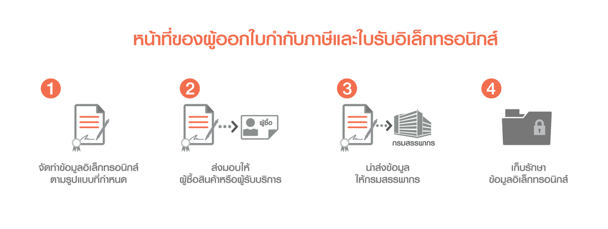

## การจัดทำข้อมูลใบกำกับภาษีอิเล็กทรอนิกส์และใบรับอิเล็กทรอนิกส์

### การออกใบกำกับภาษีอิเล็กทรอนิกส์หรือใบรับอิเล็กทรอนิกส์ ส่งมอบให้ผู้ซื้อสินค้า และผู้รับบริการ

```
ผู้ประกอบการสามารถจัดทำข้อมูลใบกำกับภาษีอิเล็กทรอนิกส์หรือใบรับอิเล็กทรอนิกส์ที่มี สาระสำคัญของใบกำกับภาษี ตามมาตรา 86/4 แห่งประมวลรัษฎากร ใบเพิ่มหนี้ตามมาตรา 86/9 แห่งประมวลรัษฎากร ใบลดหนี้ตามมาตรา 86/10 แห่งประมวลรัษฎากร และใบรับตามมาตรา 105 ทวิ แห่งประมวลรัษฎากร โดยมีทางเลือกในการจัดทำใบกำกับภาษีอิเล็กทรอนิกส์ และใบรับอิเล็กทรอนิกส์ ได้ 2 ทางเลือกดังนี้
```

1. จัดทำข้อมูลรูปแบบ XML File ตามมาตรฐานที่กำหนด ซึ่งต้องลงลายมือชื่อดิจิทัล (Digital Signature)
2. จัดทำข้อมูลรูปแบบอิเล็กทรอนิกส์อื่นๆ เช่น Word, PDF, PDF/A-3 ซึ่งต้องลงลายมือชื่อดิจิทัล (Digital Signature)

### การจัดเตรียมข้อมูลนำส่งกรมสรรพากร

1. ข้อมูลที่ต้องจัดทำเป็นรูปแบบอิเล็กทรอนิกส์และนำส่งกรมสรรพากร ได้แก่
   - ใบกำกับภาษี (Tax Invoice)
   - ใบเพิ่มหนี้ (Debit Note)
   - ใบลดหนี้ (Credit Note)
   - ใบรับ (Receipt)
2. จัดทำใบกำกับภาษีหรือใบรับให้อยู่ในรูปแบบข้อมูลอิเล็กทรอนิกส์ที่มีโครงสร้างข้อมูล XML File ตามข้อเสนอแนะมาตรฐานด้านเทคโนโลยีสารสนเทศ และการสื่อสารที่จำเป็นต่อธุรกรรมทางอิเล็กทรอนิกส์ ว่าด้วยข้อความอิเล็กทรอนิกส์ สำหรับการซื้อขายสินค้าและบริการ (ขมธอ.3-2560) เท่านั้น
3. ข้อมูล XML ที่จัดทำต้องลงลายมือชื่อดิจิทัล (Digital Signature) ด้วยใบรับรองอิเล็กทรอนิกส์ ของผู้ประกอบการ ที่ออกโดยผู้ให้บริการออกใบรับรองอิเล็กทรอนิกส์ ที่อยู่ภายใต้การรับรองของผู้ให้บริการออกใบรับรองอิเล็กทรอนิกส์ (Thailand National Root Certification Authority หรือ Thailand NRCA) และภายใต้การกำกับดูแลของสำนักงานพัฒนาธุรกรรมทางอิเล็กทรอนิกส์ สำหรับผู้ประกอบการที่ต้องการพัฒนาระบบลงลายมือชื่อดิจิทัลด้วยตนเอง ให้ศึกษาขั้นตอนการจัดทำและสร้างลายมือชื่อดิจิทัล ที่คู่มือการจัดทำและลงลายมือชื่อดิจิทัลใบกำกับภาษีอิเล็กทรอนิกส์และใบรับอิเล็กทรอนิกส์ในรูปแบบ XML ตามข้อเสนอแนะของสำนักงานพัฒนาธุรกรรมทางอิเล็กทรอนิกส์
4. นำส่งข้อมูลผ่านช่องทางนำส่งของกรมสรรพากร **ภายในวันที่ 15 ของเดือนภาษีถัดไป**

### การตรวจสอบโครงสร้างข้อมูล XML (Schema และ Schematron)

```
การนำส่งข้อมูลใบกำกับภาษีอิเล็กทรอนิกส์และใบรับอิเล็กทรอนิกส์ให้กรมสรรพากร ระบบจะตรวจสอบโครงสร้างข้อมูลตามหลักเกณฑ์และเงื่อนไขที่กำหนด (Schema และ Schematron) ว่าเป็นโครงสร้างข้อมูล XML ตามมาตรฐานที่กำหนดหรือไม่ เช่น ตรวจสอบประเภทของข้อมูล ความยาวของข้อมูล ความสัมพันธ์ของข้อมูล เป็นต้น และตรวจสอบใบรับรองอิเล็กทรอนิกส์ที่ใช้งาน ไม่หมดอายุ หรือไม่ถูกเพิกถอน รวมทั้งการตรวจสอบลายมือชื่อดิจิทัล (Digital Signature) ที่รับรองว่าข้อมูลของผู้นำส่งไม่ถูกเปลี่ยนแปลงแก้ไข กรณีนำส่งไม่สำเร็จ ระบบจะแสดงข้อความตอบกลับให้ทราบว่ามีรายการใดที่ไม่ถูกต้องให้ผู้นำส่งจัดทำไฟล์ให้ถูกต้องและนำส่งข้อมูลใหม่

ผู้ประกอบการที่พัฒนาระบบการจัดทำใบกำกับภาษีอิเล็กทรอนิกส์และใบรับอิเล็กทรอนิกส์ด้วยตนเอง แนะนำให้ตรวจสอบโครงสร้างข้อมูล XML File และการลงลายมือชื่อดิจิทัล (Digital Signature) ว่าเป็นไปตามเงื่อนไขที่กำหนดหรือไม่ ก่อนทำการนำส่งข้อมูล
```

### การตรวจสอบความถูกต้องของโครงสร้างข้อมูล XML (Schema และ Schematron)

1. ตรวจสอบไฟล์ XML ผ่านเว็บไซต์ ที่เมนู สนับสนุน > ตรวจสอบโครงสร้างข้อมูล
2. นำไฟล์ที่จัดทำขึ้นเปรียบเทียบกับชุดข้อมูล XML Schema ผ่านโปรแกรมตัวช่วย เช่น โปรแกรม XML Spy เป็นต้น (ดาวน์โหลดไฟล์สำหรับตรวจสอบโครงสร้างข้อมูล XML ได้ที่ เมนู สนับสนุน > ดาวน์โหลดโปรแกรม)

# ใบรับรองอิเล็กทรอนิกส์ (Electronic Certificate)

```
คือ ข้อมูลอิเล็กทรอนิกส์หรือการบันทึกอื่นใด ซึ่งยืนยันความเชื่อมโยงระหว่างเจ้าของลายมือชื่อดิจิทัล (Digital Signature) กับข้อมูลสำหรับใช้สร้าง ลายมือชื่อดิจิทัล ที่ออกโดยผู้ให้บริการออกใบรับรองอิเล็กทรอนิกส์ (Certification Authority - CA) เพื่อใช้บ่งบอกถึงความมีตัวตนที่แท้จริงในโลกแห่งอิเล็กทรอนิกส์ โดยผู้ให้บริการออกใบรับรองจะทำการรับรองข้อมูลต่าง ๆ ซึ่งรวมถึงกุญแจสาธารณะที่ปรากฏในใบรับรองอิเล็กทรอนิกส์ว่าเป็นของบุคคลนั้นจริง โดยอาศัยเทคโนโลยีความปลอดภัยของข้อมูล ที่เรียกว่า เทคโนโลยีโครงสร้างพื้นฐานกุญแจสาธารณะ (Public Key Infrastructure – PKI)
```

### ใบรับรองอิเล็กทรอนิกส์ สามารถนำไปใช้ใน 2 ลักษณะ

```
1. การลงลายมือชื่อดิจิทัล (Digital Signature) คือ การรับรองข้อมูลอิเล็กทรอนิกส์ที่ส่งมานั้นเป็นข้อมูลที่ส่งโดยผู้ส่งที่อ้างไว้จริง และใช้ลายมือชื่อดิจิทัลนี้ในการตรวจสอบข้อมูลว่ามีการปลอมแปลงในระหว่างขั้นตอนการส่งหรือไม่ เช่น การลงลายมือชื่อดิจิทัลกำกับจดหมายอิเล็กทรอนิกส์ ซึ่งผู้ส่งจะใช้กุญแจส่วนตัว (Private key) ของตนทำการลงลายมือชื่อดิจิทัลกำกับจดหมายอิเล็กทรอนิกส์ฉบับนั้น ซึ่งทำให้มั่นใจได้ว่าจดหมายอิเล็กทรอนิกส์เป็นของผู้ส่งที่อ้างไว้จริง โดยในการตรวจสอบนั้นผู้รับจะต้องใช้กุญแจสาธารณะ (Public key) ที่อยู่ในใบรับรองของผู้ส่งมาทำการตรวจสอบจดหมายอิเล็กทรอนิกส์ที่ส่งมาว่ามาจากผู้ส่งจริง และไม่มีการปลอมแปลงข้อมูลระหว่างขั้นตอนการส่ง
2. การเข้ารหัสลับ (Encryption) คือ การแปรรูปข้อมูลธรรมดาให้อยู่ในรูปของข้อมูลที่ไม่สามารถ อ่านเข้าใจได้ เพื่อป้องกันมิให้ผู้อื่นล่วงรู้ข้อมูล เช่น การเข้ารหัสจดหมายอิเล็กทรอนิกส์โดยผู้ส่งจะใช้กุญแจสาธารณะ (Public key) ของผู้รับ (ซึ่งอยู่ในใบรับรองของผู้รับ) มาทำการเข้ารหัส ส่วนในการถอดรหัสผู้รับจะต้องใช้กุญแจส่วนตัว (Private key) ของตนเองมาทำการถอดรหัส ในการใช้กุญแจส่วนตัว (Private key) มาถอดรหัสนี้เป็นการมั่นใจได้ว่าผู้รับที่เป็นเจ้าของคู่กุญแจ (กุญแจส่วนตัวและกุญแจสาธารณะ) เท่านั้นที่สามารถอ่านข้อมูลได้
```

### ใบรับรองอิเล็กทรอนิกส์มีประโยชน์อย่างไร

```
ใบรับรองอิเล็กทรอนิกส์ (Certificate Authority) มีความจำเป็นและมีความสำคัญในการสร้างให้เกิดความปลอดภัย และความเชื่อมั่นในการติดต่อสื่อสารผ่านสื่ออิเล็กทรอนิกส์ อันได้แก่

1. ความลับของข้อมูล (Data Confidentiality) เพื่อป้องกันไม่ให้ผู้อื่นที่มิได้รับอนุญาตหรือไม่มีสิทธิมาอ่านข้อมูลอิเล็กทรอนิกส์
2. ความครบถ้วนของข้อมูล (Data Integrity) สามารถตรวจสอบได้ว่า ข้อมูลที่ได้รับมีความถูกต้องครบถ้วน และไม่ถูกเปลี่ยนแปลงแก้ไข
3. การพิสูจน์ตัวจริง (Authentication) เป็นการยืนยันตัวบุคคลผู้ส่งข้อมูลอิเล็กทรอนิกส์
4. การห้ามปฏิเสธความรับผิด (Non-repudiation) เป็นการป้องกันไม่ให้บุคคลผู้ส่งปฏิเสธว่าตนไม่ได้ส่งข้อมูลอิเล็กทรอนิกส์
```

ที่มา : http://www.nrca.go.th

```
ระบบการจัดทำและนำส่งข้อมูลใบกำกับภาษีอิเล็กทรอนิกส์ และใบรับอิเล็กทรอนิกส์ (e-Tax Invoice & e-Receipt) มีความจำเป็นต้องใช้งานร่วมกับ ใบรับรองอิเล็กทรอนิกส์ (Certificate Authority) เพื่อให้ผู้ใช้งานเกิดความมั่นใจปลอดภัยตามมาตรฐานสากล ดังนั้น ผู้ประกอบการจึงต้องจัดหาใบรับรองอิเล็กทรอนิกส์เพื่อใช้ในการลงลายมือชื่อดิจิทัล (Digital Signature) ที่ข้อมูลใบกำกับภาษีอิเล็กทรอนิกส์หรือใบรับอิเล็กทรอนิกส์ รวมทั้งทำรายการต่างๆ เพื่อความมั่นใจในการทำธุรกรรมอิเล็กทรอนิกส์ซึ่งเป็นการยืนยันตัวตนและรับรองความถูกต้องของข้อมูล
```

### ข้อกำหนดเกี่ยวกับใบรับรองอิเล็กทรอนิกส์

```
1. ผู้ประกอบการต้องขอใบรับรองอิเล็กทรอนิกส์สำหรับนิติบุคคล (Enterprise Certificate) ตามมาตรฐาน PKCS#11 (Public key Cryptography Standards#11) จากผู้ให้บริการออกใบรับรองที่ได้มาตรฐาน และกรมสรรพากรเห็นชอบ
2. ใบรับรองอิเล็กทรอนิกส์ ต้องเข้าชุดกับคู่กุญแจ (Key Pair) ซึ่งประกอบด้วยกุญแจส่วนตัว (Private Key) และกุญแจสาธารณะ (Public Key) ที่ถูกสร้างและจัดเก็บในอุปกรณ์ เพื่อใช้ในกระบวนการสร้างลายมือชื่อดิจิทัล (Digital Signature) ทั้งนี้ อุปกรณ์จัดเก็บคู่กุญแจและใบรับรองอิเล็กทรอนิกส์ ควรมีมาตรฐานความปลอดภัย FIPS140-2 ตั้งแต่ระดับ 3 ขึ้นไป
```

**ข้อแนะนำ :** ใบรับรองอิเล็กทรอนิกส์มีอายุการใช้งาน เมื่อใกล้หมดอายุผู้เป็นเจ้าของใบรับรองอิเล็กทรอนิกส์ต้องดำเนินการจัดหาใบรับรองอิเล็กทรอนิกส์ทดแทนเพื่อดำเนินการจัดทำเอกสารอิเล็กทรอนิกส์ได้อย่างต่อเนื่อง

### กรมสรรพากรกำหนดให้ใช้ใบรับรองอิเล็กทรอนิกส์ในการยืนยันตัวตนด้วยลายมือชื่อดิจิทัล ดังนี้

```
1. ยื่นคำขอจัดทำ ส่งมอบ และเก็บรักษาใบกำกับภาษีอิเล็กทรอนิกส์ และใบรับอิเล็กทรอนิกส์ (บ.อ.01)
2. ยื่นคำขอแจ้งการเปลี่ยนแปลงจัดทำ ส่งมอบ และเก็บรักษาใบกำกับภาษีอิเล็กทรอนิกส์ และใบรับอิเล็กทรอนิกส์ (บ.อ.09)
3. ลงลายมือชื่อดิจิทัลเพื่อจัดทำใบกำกับภาษีอิเล็กทรอนิกส์ หรือใบรับอิเล็กทรอนิกส์
```

# YouTube : e-Tax Invoice & Receipt by RDX Platform

## e-Tax Invoice & Receipt by RDX Platform ตอนที่ 1 : https://www.youtube.com/watch?v=UeXSSSINZUc

```python
# https://www.youtube.com/watch?v=UeXSSSINZUc
YouTubeVideo('UeXSSSINZUc', 800, 450)
```

<iframe allowfullscreen="" frameborder="0" height="450" src="https://www.youtube.com/embed/UeXSSSINZUc" width="800"></iframe>

## e-Tax Invoice & Receipt by RDX Platform ตอนที่ 2 : https://www.youtube.com/watch?v=Nv3iRIGGwYk

```python
# https://www.youtube.com/watch?v=Nv3iRIGGwYk
YouTubeVideo('Nv3iRIGGwYk', 800, 450)
```

<iframe allowfullscreen="" frameborder="0" height="450" src="https://www.youtube.com/embed/Nv3iRIGGwYk" width="800"></iframe>

```python
from IPython.display import HTML
HTML('<iframe width="700" height="300" src="https://drive.google.com/file/d/1MJCa96zHQRD2KQU2hxRLQePWuVPQC-V4/view" frameborder="0" allowfullscreen></iframe>')
```

<iframe allowfullscreen="" frameborder="0" height="300" src="https://drive.google.com/file/d/1MJCa96zHQRD2KQU2hxRLQePWuVPQC-V4/view" width="700"></iframe>

# Partnership

[figure not shown]

# RDX Platform

## What is the RDX Platform?

[figure not shown]

## RDX Work Flow

[figure not shown]

## How to interface with RDX Platform?

[figure not shown]

## RDX Gateway Client Module Type

[figure not shown]

## RDX Secure Docs Model

[figure not shown]

## RDX Biz Exchange Services

[figure not shown]

## ลักษณะของการเชื่อมต่อข้อมูลกับ RDX Platform

```
   ระบบได้ออกแบบมาเพื่อไม่ให้เข้าไปยุ่งเกี่ยวกับระบบของ Partner ใด ๆ ทั้งสิ้น ไม่ว่าจะเป็น hardware หรือ software เพื่อป้องกันปัญหาการแทรกแซงข้อมูลของลูกค้า และ ผลข้างเคียงอันอาจจะเกิดจากการทำงานของระบบ ปัญหาหลักของการทำงานข้าม Platform คือ การเข้าถึงข้อมูลโดยตรงระหว่างกัน ซึ่งเมื่อมีข้อผิดพลาดเกิดขึ้นในการทำงาน การตรวจสอบข้อมูลถึงสาเหตุของปัญหา เป็นการตรวจสอบที่ใช้เวลาค่อนข้างมาก หากทั้ง 2 Platform เป็นคนละหน่วยงานกัน อาจจะเกิดปัญหาการโยนความผิดให้กัน ส่งผลกระทบไปกับทุก ๆ ฝ่าย
```

**เราได้ออกแบบการเชื่อมต่อระบบไว้ 2 ลักษณะ ได้แก่**

```
1. File System : เหมาะสำหรับระบบงานแบบเดิม ที่ไม่สามารถปรับเปลี่ยนอะไรได้มาก เป็นการเชื่อมต่อข้อมูลระหว่างระบบด้วย Text File ผ่าน Shared Folder ที่ตกลงกัน ทั้งการส่งข้อมูล การรับข้อมูล และ การตรวจสอบข้อผิดพลาดจากสาเหตุต่างๆ เพื่อไม่ให้ส่งผลกระทบกับการทำงานของทั้ง 2 Platform

2. Web Service : เหมาะสำหรับระบบงานที่สามารถเรียกใช้  Web Service ได้ โดยการรับส่งข้อมูลผ่าน Web Service API ที่กำหนด โดยสามารถเปลี่ยนวิธีการจาก Call Web Service เปลี่ยนเป็น REST API แทนได้
```

## กระบวนการส่งข้อมูล e-Tax Invoice ของกรมสรรพาการทางอิเล็กทรอนิกส์

[figure not shown]

## Method 1 : การส่งข้อมูลไปกรมสรรพากร โดยการเชื่อมต่อแบบ File System

### RDX Platform File System Interface Concept

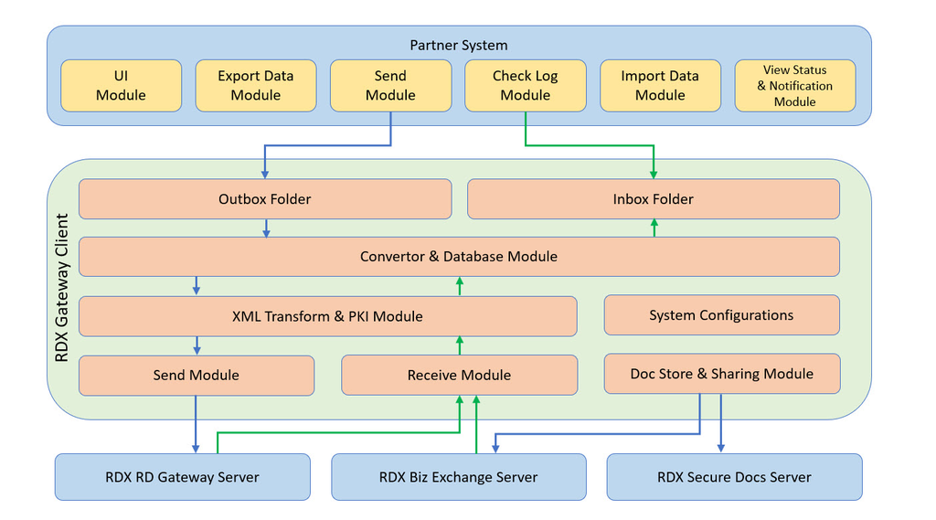

### Partner File System Interface

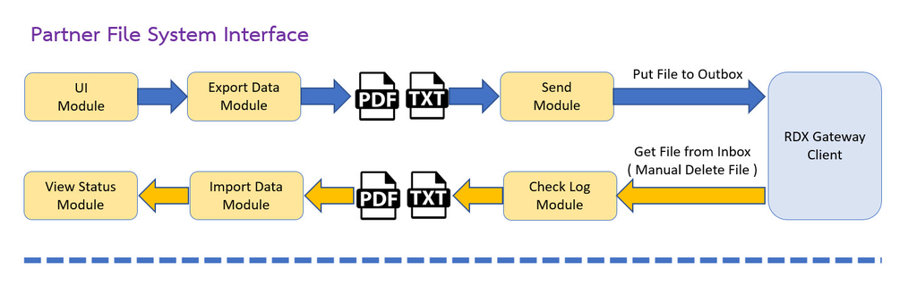

### ขั้นตอนการทำงาน (File System)

1. Shared Folder ‘D:\ECS-SYS\AutoSend’ ที่เครื่อง RDX Gateway Client ภายใน Folder นั้นจะมี Folder ย่อยคือ Inbox, Outbox
2. Map Network Drive ให้ไปชี้ที่ Shared Folder ในข้อ 1 ของเครื่องของ RDX Gateway Client
3. สร้างข้อมูลเอกสารตาม Flat File Layout ที่ RDX Platform กำหนด
4. Copy File ไปยัง Folder ‘Outbox’ ที่ Map ไว้ กรณีที่มี PDF File ให้ Copy PDF File ส่งมาให้ด้วย โดยตั้งชื่อไฟล์ PDF เป็น TAXNO_DOCTYPE_DOCNO.PDF เช่น 1052903456_ETAXINVOICE_0199123.PDF เป็นต้น (ห้ามมีเครื่องหมายสัญลักษณ์ใดๆ ในชื่อไฟล์)
5. ระบบ RDX Gateway Client จะทำการตรวจสอบ File ใน Folder ‘Outbox’ แล้วจะทำการ Import ข้อมูลลงใน Database ของระบบ
6. ระบบจะส่ง Log File กลับมาที่ Folder Inbox เพื่อให้โปรแกรมได้ตรวจสอบว่า ข้อมูลที่ส่งเข้ามา ถูกต้องหรือไม่ รวมถึง Response ต่างๆ
7. ระบบ RDX Gateway Client จะ Scan ข้อมูลใน Database ของระบบเพื่อตรวจสอบว่ามีข้อมูลเข้ามาใหม่หรือไม่ ถ้ามีข้อมูลใหม่ ระบบจะทำการสร้างข้อมูล XML จากเอกสารชุดนั้น พร้อมลงลายมือชื่ออิเล็กทรอนิกส์
8. ระบบ จะส่งข้อมูล ต่อไปให้กับ RDX RD Gateway เพื่อส่งข้อมูลให้กรมสรรพากรต่อไป
9. เมื่อกรมสรรพากรได้รับข้อมูลแล้ว กรมสรรพากร จะส่งข้อมูลสถานะการส่งข้อมูลกลับมาให้ ว่าส่งผ่าน (Accept) หรือ ไม่ผ่าน (Reject)
10. ระบบ RDX Gateway Client จะทำการสร้าง Log File มาไว้ที่ Folder Inbox เพื่อให้โปรแกรมได้ตรวจสอบว่า สถานะส่งข้อมูล ไปที่กรมสรรพากร ถูกต้องหรือไม่
11. เมื่อข้อมูลที่ส่งให้กรมได้รับ Accept จากกรมสรรพากร ระบบลงลายมือชื่ออิเล็กทรอนิกส์ใน PDF File จากข้อ 4
12. ระบบจะ Zip เอกสาร XML File และ PDF File พร้อมเข้ารหัส ไปเก็บไว้ใน RDX Secure Doc Server และ ส่งต่อให้ RDX Biz Exchange ต่อไป

**ข้อแนะนำ :** ควรสร้างหน้าจอสำหรับรับส่งข้อมูล และ หน้าจอสถานะข้อมูล ให้กับลูกค้าได้ทราบ ถึงรายการที่เกิดขึ้นในขั้นตอนต่าง ๆ

### การตรวจสอบข้อมูล Response จากระบบ (File System)

1. RDX Gateway Client จะทำการตรวจสอบ Response ต่างๆจาก RDX Platform ถ้ามี Response ใดๆกลับมา ไม่ว่าจะเป็น RDX RD Gateway / RDX Secure Docs / RDX Biz Exchange ระบบจะสร้าง Log Record ทุกครั้ง
2. ระบบจะทำการสร้างไฟล์ต่างๆ ที่เกี่ยวข้อง ลงใน Inbox Folder
   - สร้าง Log File ตั้งชื่อเป็น LOGyyyyMMdd_0000000_TaxNo_Branch.log ( JSON String )
   - สร้าง Text File ตั้งชื่อเป็น TXT_TaxNo_Branch_RefNo.txt ( Text Pipe )
   - สร้าง PDF File ตั้งชื่อเป็น PDF_TaxNo_Branch_RefNo.pdf ( PDF File )
3. ให้ระบบของ Partner เข้ามาตรวจสอบไฟล์ใน Inbox Folder ว่ามีไฟล์ใดบ้าง
4. ทำการ Loop Log File ที่ได้ โดยการตรวจสอบค่า Log.ResType Field
   - ‘ACCEPT’ : ผลการส่งข้อมูลไปที่กรมสรรพากรสำเร็จ กรมฯ ยืนยันการรับข้อมูล ตรวจสอบเลขรับข้อมูลที่ Log.PayLoad Field
   - ‘REJECT’ : ผลการส่งข้อมูลไปที่กรมสรรพากรสำเร็จ กรมฯ แจ้งปัญหากลับมา ตรวจสอบ สาเหตุที่ REJECT จากข้อมูลที่ Log.PayLoad
   - ‘ERROR’ : มี Error จากการทำรายการ ตรวจสอบ สาเหตุที่ Error จากข้อมูลที่ Log.PayLoad
   - ‘KeepDoc’ : เก็บข้อมูลลง RDX Secure Docs เรียบร้อย
   - ‘BizX’ : ได้รับข้อมูลจากคู่ค้าผ่าน RDX Biz Exchange Server

     ให้ใช้ Text File โดยอ้างอิงจากชื่อไฟล์ TXT_TaxNo_Branch_RefNo.txt เพื่อใช้ในการนำเข้าข้อมูลเอกสารต่อไป

     ให้ใช้ PDF File ( ถ้ามี ) โดยอ้างอิงจากชื่อไฟล์ PDF_TaxNo_Branch_RefNo.pdf เพื่อใช้ในการเก็บเอกสารต่อไป ( RefNo จะได้จาก Log.RefNo Field )
5. ทำการ DELETE File ที่อ่านมาแล้ว ทั้ง Log, Text และ PDF จากใน Inbox

## Method 2 : การส่งข้อมูลไปกรมสรรพากร โดยการเชื่อมต่อแบบ Web Service

### RDX Platform Web Service Interface Concept

[figure not shown]

### Partner Web Service Interface

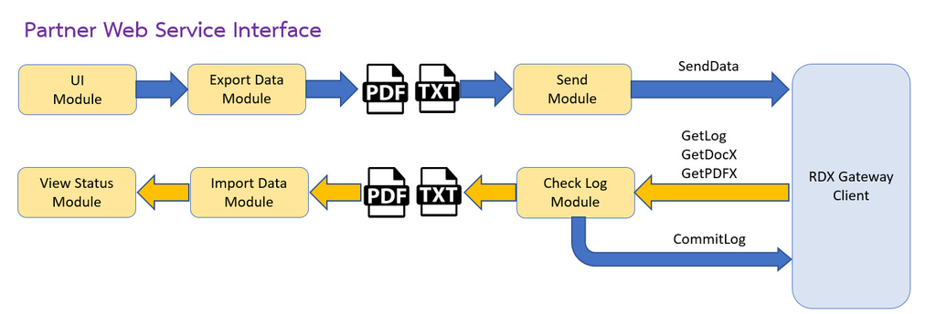

### การตรวจสอบข้อมูล Response จากระบบ (Web Service)

1. RDX Gateway Client จะทำการตรวจสอบ Response ต่างๆจาก RDX Platform ถ้ามี Response ใดๆกลับมา ไม่ว่าจะเป็น RDX RD Gateway / RDX Secure Docs / RDX Biz Exchange ระบบจะสร้าง Log Record ทุกครั้ง
2. ทำการ Call GetLog() เพื่ออ่านข้อมูล Log.StatusRead < 2 ( Function นี้จะทำให้ Log.StatusRead เปลี่ยนจาก 0 เป็น 1 )
3. ทำการ Loop Log Record ที่ได้ โดยการตรวจสอบค่า Log.ResType Field
   - **‘ACCEPT’** : ผลการส่งข้อมูลไปที่กรมสรรพากรสำเร็จ กรมฯ ยืนยันการรับข้อมูล ตรวจสอบเลขรับข้อมูลที่ Log.PayLoad Field
   - **‘REJECT’** : ผลการส่งข้อมูลไปที่กรมสรรพากรสำเร็จ กรมฯ แจ้งปัญหากลับมา ตรวจสอบ สาเหตุที่ REJECT จากข้อมูลที่ Log.PayLoad
   - **‘ERROR’** : มี Error จากการทำรายการ ตรวจสอบ สาเหตุที่ Error จากข้อมูลที่ Log.PayLoad -**‘KeepDoc’** : เก็บข้อมูลลง RDX Secure Docs เรียบร้อย
   - **‘BizX’** : ได้รับข้อมูลจากคู่ค้าผ่าน RDX Biz Exchange Server
     - Call GetDocX (Log.TaxNumber, Log.BranchCode, Log.RefNo) เพื่ออ่านข้อมูลเอกสารที่ได้รับมาสามารถตรวจสอบข้อมูลเอกสาร จากค่าที่ตอบกลับมา (Text Pipe)
     - Call GetPDFX(Log.TaxNumber, Log.BranchCode, Log.RefNo) เพื่ออ่านข้อมูล PDF ที่ Seller ส่งมา ให้ทำการแปลง Bese64 เป็น Binary เพื่อสร้าง PDF File
4. ทำการ Call CommitLog() เพื่อปรับสถานะ Log.StatusRead จาก 1 เป็น 2